# PA1_template

Jose Mendez Miquel

Sunday, September 20, 2015

# Report

The following Document is a Report that Respond the Questions associated to the basic anaylisis of certain Data containing: Steps done by an individual in the Dates covered between 2012-10-01 and 2010-11-30 in intervals of 5 minutos of aggregated time.

Previously we need to read the data and then tranform it in order to work properly with an adequated data frame, Thus, We use the function read.csv and data.framne correspondly..

# I. Read Data and Transform it

```r
# I. Read Data
setwd('/home/jmendez/reproducibleR')
activity=read.csv('activity.csv',header=TRUE,sep=',',na.string='NA')

# Establish Data Structure
myacti=activity[activity$interval==0,]
mydays=as.character(myacti$date)
myinterv=as.character(activity$interval[1:288])
mymat=matrix(data=activity$steps,nrow=288,ncol=61,dimnames=list(myinterv,mydays))
actdf = data.frame(mymat)
head(actdf)
```

```
##    X2012.10.01 X2012.10.02 X2012.10.03 X2012.10.04 X2012.10.05 X2012.10.06
## 0           NA           0           0          47           0           0
## 5           NA           0           0           0           0           0
## 10          NA           0           0           0           0           0
## 15          NA           0           0           0           0           0
## 20          NA           0           0           0           0           0
## 25          NA           0           0           0           0           0
##    X2012.10.07 X2012.10.08 X2012.10.09 X2012.10.10 X2012.10.11 X2012.10.12
## 0            0          NA           0          34           0           0
## 5            0          NA           0          18           0           0
## 10           0          NA           0           7           0           0
## 15           0          NA           0           0           8           0
## 20           0          NA           0           0           0           0
## 25           0          NA          13           0           0           0
##    X2012.10.13 X2012.10.14 X2012.10.15 X2012.10.16 X2012.10.17 X2012.10.18
```

[output cut: 62 more lines]

### Then we will expose the questions and the answers using explicit text ang plot to support that.

# II.- What is mean total number of steps taken per day ?

### For this part of the assignment, you can ignore the missing values in the dataset.

## 1. Calculate the total number of steps taken per day

## Total

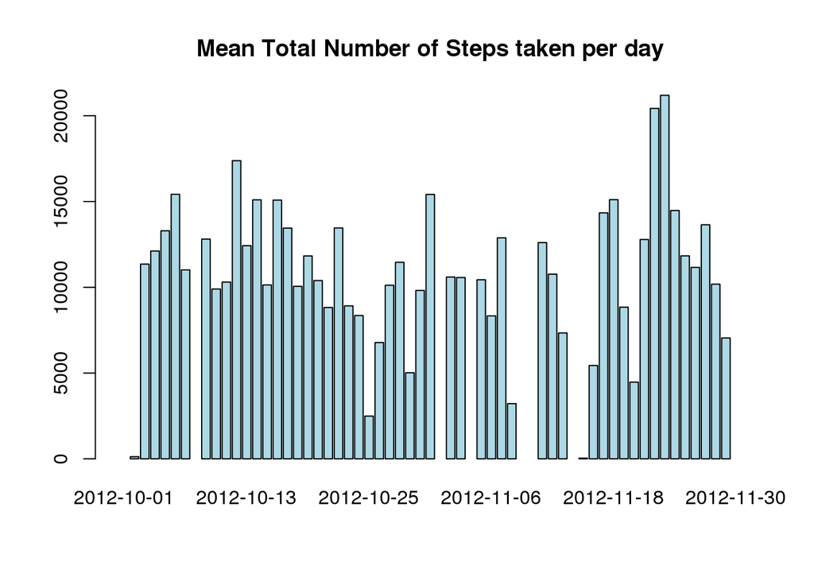

```r
totStepsDays=lapply(actdf,sum)
barplot(as.numeric(totStepsDays),names.arg=mydays,main='Mean Total Number of Steps taken per day',col='lightblue')
```

## 2. If you do not understand the difference between a histogram and a barplot, research the difference between them. Make a histogram of the total number of steps taken each day

## Histogram

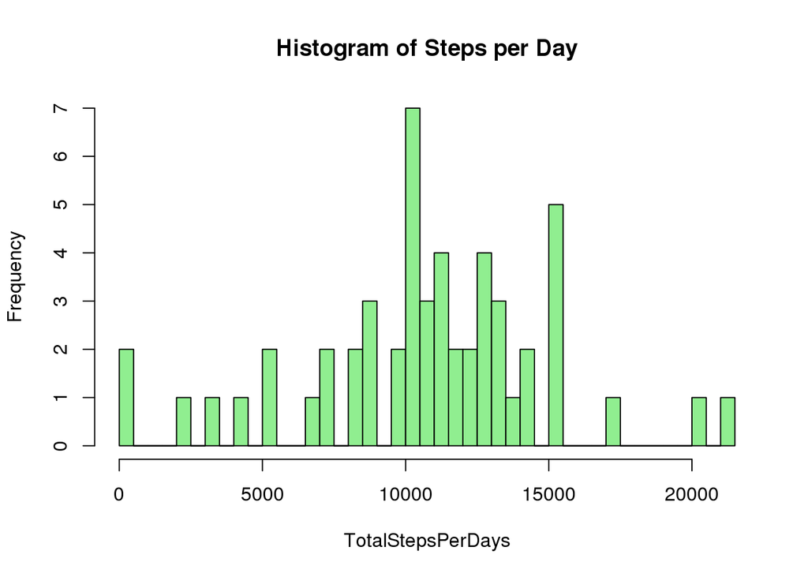

```r
hist(as.numeric(totStepsDays),breaks=40,col='lightgreen',main='Histogram of Steps per Day',xlab='TotalStepsPerDays')
```

### Histogram points to the probability distribution function

## 3. Calculate and report the mean and median of the total number of steps taken per day

## Mean

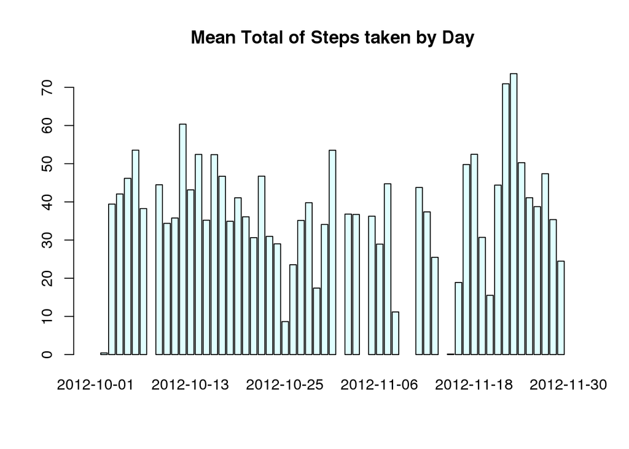

```r
meanStepsDays=lapply(actdf,mean)
barplot(as.numeric(meanStepsDays),names.arg=mydays,main='Mean Total of Steps taken by Day',col='lightcyan')
```

## Median

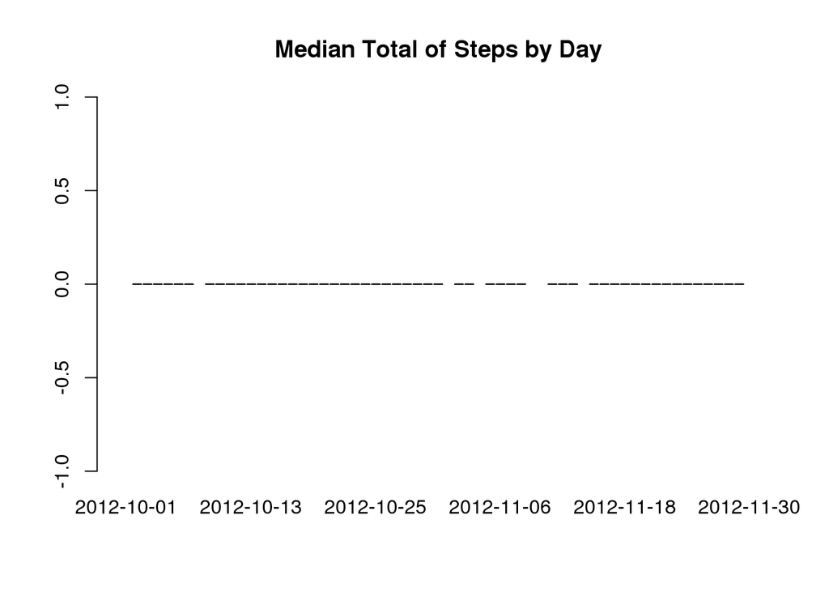

```r
medianStepsDays=lapply(actdf,median)
barplot(as.numeric(medianStepsDays),names.arg=mydays,main='Median Total of Steps by Day')
```

# III.- What is the average daily activity pattern?

## Make a time series plot (i.e. type = “l”) of the 5-minute interval (x-axis) and the average number of steps taken, averaged across all days (y-axis)

### Just and exploring data exercise…

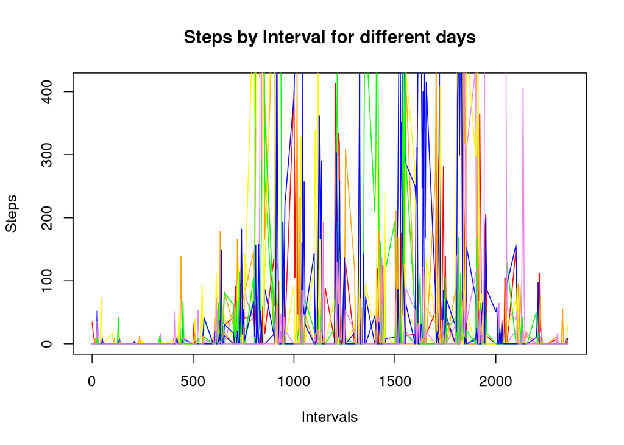

```r
# Just exploring the data...
plot(rownames(actdf), actdf$X2012.10.10,type='l',col='red',main='Steps by Interval for different days',ylab='Steps', xlab='Intervals')
points(rownames(actdf), actdf$X2012.10.11,type='l',col='orange')
points(rownames(actdf), actdf$X2012.10.12,type='l',col='yellow')
points(rownames(actdf), actdf$X2012.10.13,type='l',col='green')
points(rownames(actdf), actdf$X2012.10.14,type='l',col='blue')
points(rownames(actdf), actdf$X2012.10.15,type='l',col='violet')
points(rownames(actdf), actdf$X2012.10.16,type='l',col='orange')
points(rownames(actdf), actdf$X2012.10.17,type='l',col='yellow')
points(rownames(actdf), actdf$X2012.10.18,type='l',col='green')
points(rownames(actdf), actdf$X2012.10.19,type='l',col='blue')
points(rownames(actdf), actdf$X2012.10.20,type='l',col='violet')
```

```r
#
```

## Means Steps by Interval

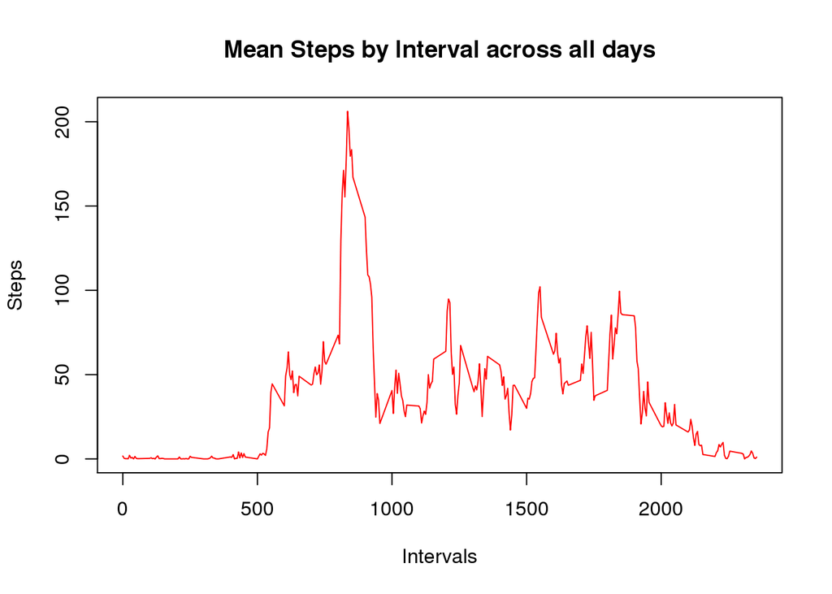

```r
meanStepsInterv=apply(actdf,1,function(x)mean(x[!is.na(x)]))
# correspondly Plot the average of steps across all days
plot(rownames(actdf), meanStepsInterv,type='l',col='red',main='Mean Steps by Interval across all days',ylab='Steps', xlab='Intervals')
```